# Using spaced repetition for learning facts, forming habits, and re-reading quotes

By: Andrew McKenzie; First Published: 2012-10-12; Last Updated: 2023-01-03; Status: Finished

- [Link back to the home page](https://andrewtmckenzie.com/)

## Summary

Spaced repetition is a powerful learning method, memory aid, habit reinforcer, and randomness generator that has added a lot of value to my life. I give a brief introduction to spaced repetition learning, why I’ve found it useful, and a few of the lessons I’ve picked up along the way. Then, I link to some of my current shared decks, broken down by topic, made using the free, open-source software [Anki](http://ankisrs.net/).

## Introduction

Most of the time, it is acceptable to learn something in the short run and accept that you will probably forget it later. Maybe you don’t care about the material long-term and just want to pass a course. Or maybe you need to understand a topic well enough to execute a two-month long project, and after that you have good reason to expect the knowledge will lose its value.

But sometimes forgetting information is needlessly inefficient. For example, if you learn some aspect of statistics in a course and want to be able to apply it in your research career over the next 10 to 20 years.

The US, where I went to school, has a semester-based system that incentivizes you to learn topics briefly — at worst for one exam, at best for one or two semesters — and implicitly expects you to remember them from then on. This is an excellent way to temporarily store information for a few days or months, but is not an efficient way to stabilize long-term memories.

Let’s step back and look at some of the science of memory. When it comes to memory, there are two effects we want to take advantage of.

The first is the [spacing effect](http://en.wikipedia.org/wiki/Spacing_effect), which is the finding that humans learn things better when they recall them in spaced intervals over a series of hours, days, weeks, or months, rather than the same number of times massed all at once. Taken to its logical extreme, the effect suggests that there is an optimal point at which it is best to recall something, which is when you are about to forget it.

These [forgetting curves](https://en.wikipedia.org/wiki/Forgetting_curve) were mapped by Hermann Ebbinghaus in a manuscript published in 1885. If you want to learn something long-term and are able to use spaced repetition to do so, harnessing the spacing effect is close to a free lunch.

The second effect is the [testing effect](http://en.wikipedia.org/wiki/Testing_effect), which is the finding that humans learn better when they actively recall or use a fact/definition/idea instead of passively reading or hearing it. This is less of a free lunch, though, because actively recalling something does seem to take more mental energy than just reading it or hearing it. But it’s still quite powerful if you can muster the willpower.

Computer-based spaced repetition (SR) flashcard software allows you to harness both of these effects in a convenient way. The algorithms are automatically set to query and refresh your memory of a topic when they estimate that you are likely to forget it. Based on Ebbinghaus’s forgetting curves, study interval periods expand with repetitions. So, for example, after first learning a flashcard, you will be re-tested on it in (approximately) 1 day, then 4 days, then 12 days, then 1 month, then 3 months, then 9 months, etc.

By taking advantage of the spacing effects and testing effects, spaced repetition will allow you to learn in ways that are more likely to stick.

## Spaced repetition for learning facts

Most people use spaced repetition flashcards for learning facts — definitions, dates, names, relationships, nuances.

In general, the simpler and more precise the fact, the easier it is learn the memory. This is in part because the cue-recall process is faster, and in part because it is easier to evaluate whether you got a flashcard right if the fact is simpler/smaller/shorter/more precise. Simpler facts also can make it more fun to review your flashcard sets, since they tend to be less mentally taxing. But longer facts can sometimes be more helpful when you want to apply your knowledge, as you can bring to mind all the relevant info in one “chunk.” It’s best to figure out what works for you in different situations.

As of the 2010s, when I was most into the spaced repetition community, the main two applications for spaced repetition were language learning and medical school.

Language learning is kind of obvious — translation between languages lends itself very well to short, one-word facts, and there are clearly definable goals.

### Spaced repetition for medicine

Med school has just the right confluence of factors to lend itself to spaced repetition learning: huge career incentives to do well on memorization-based exams, positive social feedback because for better or worse medicine has a culture of memorization, plausible future benefits to patients in knowing more facts, and an endless volcano of relationships between diseases, symptoms, treatments, and side effects that can absorb as much time as you want to pour into it. If you’re interested to see how this works, one of the major communities for it has been r/medicalschoolanki.

An aside on using Anki for med school since I poured a lot of time into this myself: One of the most difficult but necessary things to learn is lists. Lists are everywhere in medicine, coming up as symptoms, treatments, side effects, etc.

What has worked for me to memorize lists is to make separate flashcards: one as an overall mnemonic for the list, and then separate flashcards for up to three of the members of the list at a time. A good mnemonic is short — this will make it harder to learn, but when you actually need to recall the mnemonic when you are talking to a patient, on a multiple choice test, or on rounds, you will be time-limited and need to the recall the mnemonic quickly. This is mostly for making your own cards, which I did a lot of, but now I would recommend using one of the high quality, pre-made decks.

### Spaced repetition for science research

When I was doing full-time science research during my PhD, I was mostly using spaced repetition flashcards for learning two types of things:

1: Learning programming languages, both the syntax and the vocabulary.

Syntax was most helpful when I was remembering the names of functions that I use a moderate amount — enough to justify time spent on the flashcard, but not enough that I would remember it even without a flashcard.

Vocabulary related to programming concepts has probably been more helpful, because it helps me figure out the Google search terms I should use in order to solve a problem, which is the most important thing for the type of programming I do. Examples here include terms related to recursion, matrices, parallelization, and functional programming.

2: Learning about my research topics, e.g., Alzheimer’s and genomics. The jury is still out on whether this is a good use of time, but in general, I would say to not sleep on it if you’re a researcher. For example, at the cutting edge of any research field, understanding the history of why opinions have formed, and where the evidence is weak vs strong, is essential. Instead of exclusively reading new material, there’s often more value to be gained from memorizing and systematically reflecting upon key points from material you’ve already read, especially if you have a highly imperfect memory like me.

### Spaced repetition for personal trivia

I’ve also used spaced repetition for learning facts related to my personal life — people’s names, where they went to school, what is important to them, anniversaries, etc. The possibilities are endless. If you’re bad at remembering names, adopting a habit to make a flashcard with someone’s name after you meet them and then to review it is an easy way to get good at it.

## Spaced repetition for forming habits

Spaced repetition learning acknowledges that memory recall success decays over time and that recalling a fact can refresh its memory.

My hypothesis here is that you can do spaced repetition habit formation by acknowledging that unpracticed habit automaticity decays over time and that reminding yourself of a habit can help you to build automaticity around it.

First, what is habit automaticity? This is the idea that deeply ingrained habits occur effortlessly, without the need for conscious decision-making. Automatic is the state that people want the habits they consider healthy to be in, and their unhealthy habits out of. It’s like flossing once a day, not necessarily because you want to, but just because that’s what you do.

Habit automaticity takes a long time to build. One study found that, depending on the complexity of the habit, it took anywhere from 18 to 254 days to get a habit to 95% automaticity, with a median of 66 days [(Lally et al., 2010)](https://onlinelibrary.wiley.com/doi/abs/10.1002/ejsp.674). And this was for daily habits like ‘drinking a bottle of water with lunch’; if you’re trying to build a moderately complex habit that you do less frequently, it might take even longer.

The idea behind spaced repetition habit formation is that you create a flashcard with the same expanding time schedule as a normal flashcard. However, when you see this type flashcard, your job isn’t to remember a fact, but to think to yourself about how automatic the habit on the flashcard is.

If the habit isn’t automatic at all, then you click “Wrong” and you will see the habit again tomorrow.

If the habit is super automatic, then you can click “Good” and you won’t see the habit flashcard again for quite a few days.

The habit doesn’t even need to be an action that you perform externally — it can be a purely mental habit that you’re trying to form or break.

You will be reminded of the habits that you are trying to form, in case you have simply forgotten about them. This is especially good for habits that you may have formed months or years ago but forgotten about over time. Maybe you won’t want to keep doing them — that’s a good realization and you can just delete or suspend the flashcard.

By having a structured time to think about whether you are performing the habit or not, you have an opportunity to give yourself some reinforcement or credit for a job well done. You can tell which habits you are struggling with and may need to devote more energy to by looking at the statistics of the habit cards over time.

Habit flashcards will likely be deeply personal. The ones that work for me probably wouldn’t be as helpful for you, and vice versa. That said, in the spirit of being concrete, here are a few of the habit flashcards that I have the most reviews for over the past few years:

- “I have yet to meet a successful scientist who lacks the ability to exaggerate the importance of what he or she is doing, and I believe that someone who lacks a delusional sense of significance will wilt in the face of repeated experience of multiple small failures and rare successes, the fate of most researchers.” – Daniel Kahneman, Thinking, Fast and Slow [(Kahneman, 2011)](https://en.wikipedia.org/wiki/Thinking,_Fast_and_Slow) – Created 2014-08-24, 502 reviews as of 2023-01-03
- Write at least a little bit of an academic paper, book, or grant every Monday-Friday. People who were assigned to write every weekday wrote 9x as much as those who wrote in marathon sessions. - Created 2015-03-11, 481 reviews as of 2023-01-03
- What we fear doing most is usually what we most need to do. - Tim Ferriss, The 4-Hour Workweek [(Ferriss, 2009)](https://en.wikipedia.org/wiki/The_4-Hour_Workweek) - Created 2012-03-28, 361 reviews as of 2023-01-03
- The key to positivity according to cognitive reappraisal is to accept reality as it is, but reframe whatever happens to you or might happen to you as having an upside. - Created 2014-11-04, 358 reviews as of 2023-01-03
- “Envy is the worst passion, and preys on the spirits, which again prey on the body. And it is so much the worse, because it is always at work, and (as they say) keeps no holidays.” - Francis Bacon, A History of Life and Death [(Bacon, 2005)](https://quod.lib.umich.edu/e/eebo/A01446.0001.001?view=toc) - Created 2019-06-25, 305 reviews as of 2023-01-03
- If you want to learn a topic, you should program yourself to enjoy learning about it. – Created 2013-6-22, 186 reviews as of 2023-01-03
- “If you ever find yourself buffering on output, rather than making hesitation noises, just pause. People will read that as considered deliberation and intelligence. It’s outrageously more effective than the equivalent amount of emm, aww, like, etc. Practice saying nothing. Nothing is often the best possible thing to say.” [Patrick McKenzie](https://news.ycombinator.com/item?id=6199544), – Created 3/6/2017, 121 reviews as of 11/18/18

I have about 200 active habit flashcards at a time, and do about 10-20 reviews a day. These are my favorite reviews to do because they don’t require as much cognitive load as recall, and I will do them even when I don’t have the energy to do memory recall flashcards.

Remember that there is no “right answer” to these. Rather, they are an opportunity for you to introspect about how well you are achieving the habit and whether you want to devote more resources to it, refine the habit, or abandon it.

If you try out or are interested in trying out habit flashcards, I would love to hear whether you find them helpful and/or ways that the system could be improved.

## Spaced repetition for re-reading quotes or re-viewing images

In addition to memory recall flashcards and habit flashcards, I also have a separate deck where I copy in quotes or images that I enjoy — famous ones, quotes from articles I like, quotes from my friends and family, beautiful photos of nature, famous artwork, particularly funny memes, random thoughts I have, etc. Because I do not turn the information into a question about a particular fact, I am giving up the testing effect, and I don’t tend to retain the knowledge very well. But they are low-effort to make, it is nice to review them when I have low energy, and I don’t care as much about free recalling the information as I do about periodically reminding myself of them. I view this as a way to add randomness to my life by having a conversation with myself over a longer period of time.

## My overall spaced repetition experience

Although I’ve been doing spaced repetition via Anki since February 2011, I wanted to start doing SR flashcards for several years before I actually started — approximately speaking, since May 2008, when I read [this Wired article about Piotr Wozniak](http://www.wired.com/2008/04/ff-wozniak/?currentPage=all). Wozniak truly devoted himself to spaced repetition. He seemed like an interesting person, his technique seemed like a good use of my time, and I wanted to do it.

For the next 3 years after that I had a fairly constant low level of guilt/anxiety about how I should be doing SR flashcards. This anxiety spiked whenever I forgot something I had previously learned. Of course, after a year or so, I thought it was too late and that I was a lost cause with respect to spaced repetition.

(Coincidentally, I now have a habit flashcard for how to counteract this exact flaw in my psychology. I call it “future weaponry” — when you see something cool that others are using, instead of thinking about what you could have done with a particular tool/knowledge/ability in the past, choose to think about what you will be able to do with it in the future.)

Spaced repetition flashcards weren’t really feasible, though, until I got a smartphone. Say what you want about smartphones with respect to productivity overall, but the ability to do spaced repetition flashcards on them while walking and waiting around is for me, their killer app. And this basically requires easy syncing via an internet connection.

Looking back at my cards from when I started, they’re pretty terrible. For example, I used tons of [cloze deletion](https://en.wikipedia.org/wiki/Cloze_test) cards, a lazy and less effective way of making flashcards, rather than thinking about what knowledge I really wanted to retain and framing it in question form. I was also obsessed with memorizing math equations even though these have been pretty much completely useless.

That said, by far the most important thing for me back then was to enjoy myself and maintain motivation, and I’ve been able to do that so far. I recommend you also try not to sweat the details as you begin your journey in spaced repetition.

## Decks

### Math

[Here](https://ankiweb.net/shared/info/535675942) is a link to the deck. Major sources:

- Dan Klein’s “Lagrange Multipliers without Permanent Scarring,” tutorial, pdf. Under the tag “LAGR.”
- [Wikipedia’s article](http://en.wikipedia.org/wiki/Complex_number) on complex numbers.
- Santo Fortunato’s “Community detection in graphs,” article, [arxiv](http://arxiv.org/abs/0906.0612). This is a major source for the “NETW” tag.

### Programming

Here are links to the [basic R](https://ankiweb.net/shared/info/609701403) and [intermediate R](https://ankiweb.net/shared/info/1145032819) decks. Major source:

- An introduction to R, [pdf link here](https://cran.r-project.org/doc/manuals/r-release/R-intro.pdf).
- Hadley’s Advanced R, [link here](http://adv-r.had.co.nz/).

### Psychology

[Here](https://ankiweb.net/shared/info/153746441) is a link to the shared deck. Major sources:

- Wikipedia’s [list of cognitive biases](http://en.wikipedia.org/wiki/List_of_biases_in_judgment_and_decision_making). A major source for the “BIAS” tag.
- [Wikipedia’s article](https://andrewtmckenzie.com/spaced_repetition/en.wikipedia.org/wiki/Big_Five_personality_traits) on the Big Five personality traits. A source for the “PERS” tag.
- [Dan Ariely’s RSA Animate video](http://www.youtube.com/watch?v=XBmJay_qdNc): The Truth About Dishonesty. Referenced under the search term “Ariely.”
- [Memory-related terms from Eric Kandel’s book](http://www.amazon.com/gp/product/0071390111) “The Principles of Neuroscience”
- Psychological nuggets from [Jonathon Haidt’s book “The Happiness Hypothesis”](http://www.amazon.com/The-Happiness-Hypothesis-Finding-Ancient/dp/0465028020)
- Psychological nuggets from Sarah Perry’s [book “Every Cradle is a Grave”](http://www.amazon.com/Every-Cradle-Is-Grave-Rethinking/dp/0989697290)
- Reinforcement learning and animal behavior, some from [“Learning and Behavior,” Paul Chance’s book, amazon](http://www.amazon.com/Learning-Behavior-Active-Edition/dp/0495095648). Under the “BEHA” tag.

### Statistics

[Here](https://ankiweb.net/shared/info/1910277426) is a link to the basic statistics and intuition deck. Major sources:

- Judea Pearl’s ”Causal inference in statistics: An overview”; [paper](http://projecteuclid.org/DPubS?service=UI&version=1.0&verb=Display&handle=euclid.ssu/1255440554). Pearl calls this “everything I know about statistics in only 40 pages.” A major source for the “CAUS” tag.
- Edwin Jaynes’ [Probability Theory: The Logic of Science; amazon](http://www.amazon.com/Probability-Theory-Science-T-Jaynes/dp/0521592712). Heavily Bayesian. A major source for the “BAYS” tag.
- [Cosma Shalizi’s “Advanced Data Analysis from an Elementary Point of View”](http://www.stat.cmu.edu/~cshalizi/ADAfaEPoV/). Noted as the Shalizi reference.
- [Bayesian Data Analysis, by Devinderjit Sivia and John Skilling](http://www.amazon.com/Data-Analysis-Bayesian-Devinderjit-Sivia/dp/0198568320). The first five chapters. Noted as the “S&S” reference; also a major source for the “BAYS” tag.
- [Wikipedia’s list of probability distributions](http://en.wikipedia.org/wiki/List_of_probability_distributions) – the major ones. A major source for the “DSTN” tag.
- [Lindsay Smith’s Tutorial on PCA](http://www.cs.otago.ac.nz/cosc453/student_tutorials/principal_components.pdf).
- [Philipp Janert’s book Data Analysis with Open Source Tools](http://books.google.com/books/about/Data_Analysis_with_Open_Source_Tools.html?id=mTXnXCLXJYgC), the chapter on PCA.
- [Wikipedia’s page on eigenvalues and eigenvectors](http://en.wikipedia.org/wiki/Eigenvalues_and_eigenvectors). Under the “EIGN” tag.
- [The book “An Introduction to Statistical Learning”](http://www-bcf.usc.edu/~gareth/ISL/index.html). Excellent introduction to statistics. Gareth James, in consultation with co-authors, kindly gave me permission to post some of the figures from this book in the deck.

### Quotes

[Here](https://www.dropbox.com/s/cnzjk4sg4d04kr2/McKenzie_PublicQuotes.apkg?dl=0) is a link to my deck with a sampling of about 50 quotes that I enjoy. And [here](https://glutanimate.com/) is a link to an excellent art history deck by glutaminate that I use as a quote deck without worrying about getting the information correct.

### Download statistics

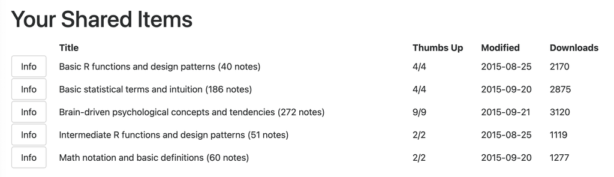

Shared Anki Deck Download Statistics as of Jan 2023

## Acknowledgments

I owe a lot to Damien Elmes, who wrote the open-source, free Anki software. I also owe a lot to Gwern, [who has written about spaced repetition extensively](https://www.gwern.net/Spaced-repetition), and who made thousands of his Mnemosyne cards available to anyone to download for free. I downloaded these one day on a whim, converted them to Anki, and that was what really made me think of having my own cards as being a realistic, practical option. Thanks, Damien and Gwern.

## References

Bacon, F., *History Of Life And Death*, Kessinger Publishing, LLC, p. 48, 2005.

Ferriss, T., *The 4-Hour Workweek: Escape 9-5, Live Anywhere, and Join the New Rich*, New York: Harmony, p. 448, 2009.

Kahneman, D., *Thinking, Fast and Slow*, Farrar, Straus and Giroux, p. 511, 2011.

Lally, P., Jaarsveld, C. H. M. van, Potts, H. W. W. and Wardle, J., How Are Habits Formed: Modelling Habit Formation in the Real World, *European Journal of Social Psychology*, vol. **40**, no. 6, pp. 998–1009, accessed December 28, 2021, from https://onlinelibrary.wiley.com/doi/abs/10.1002/ejsp.674, 2010. DOI: 10.1002/ejsp.674